Useful Functions Kylie Foster 1 May 2019

# ISL Chapter 2

### `ggpairs()`

Useful for exploratory data analysis. Produces a pairwise comparison of multivariate data. By default, `ggpairs` provides two different comparisons of each pair of columns and displays either the density (for continous variables) or count (for categorical variables) along the diagonal.

To carry out a pairwise comparison of all variables in a dataframe:

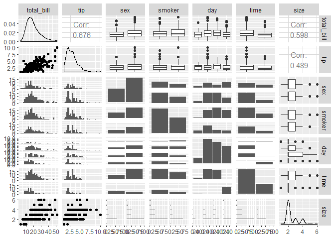

```r
data(tips, package = "reshape")
(pm <- ggpairs(tips))
```

If this creates too many subplots you can restrict the plot to a specific number of columns using:

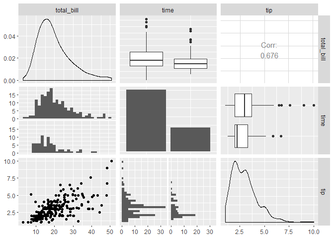

```r
(pm <- ggpairs(tips, columns = c("total_bill", "time", "tip")))
```

```r
# or equivalently you can use column numbers instead of variable names:
pm <- ggpairs(tips, columns = c(1, 6, 2))
```

To change the labels on the axes use `columnLabels`:

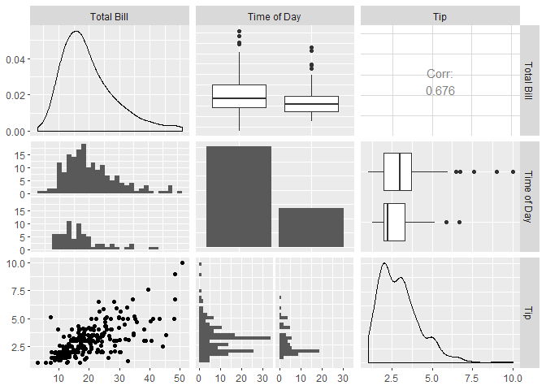

```r
(pm <- ggpairs(tips, columns = c("total_bill", "time", "tip"), columnLabels = c("Total Bill", "Time of Day", "Tip")))
```

To apply aesthetics to all of the subplots (e.g. colour) use the `mapping` parameter:

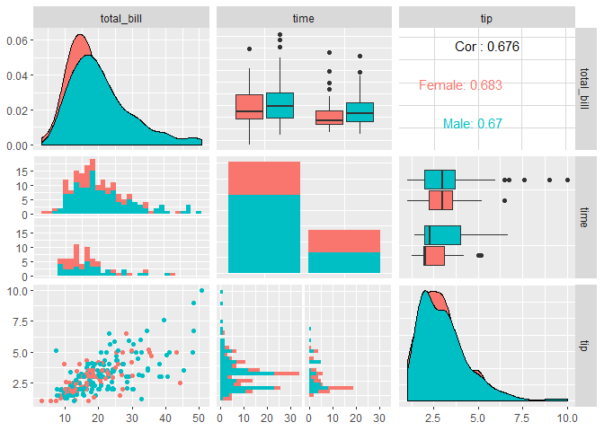

```r
(pm <- ggpairs(tips, mapping = aes(color = sex), columns = c("total_bill", "time", "tip")))
```

It is also possible to change the `theme`, for example:

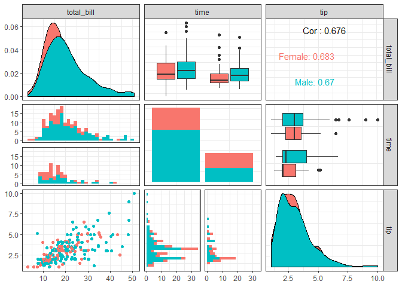

```r
(pm <- ggpairs(tips, mapping = aes(color = sex), columns = c("total_bill", "time", "tip")) +
   theme_bw())
```

For more information (including how to replace default plots with different types of plots, add trendlines etc): https://mran.microsoft.com/snapshot/2016-01-07/web/packages/GGally/vignettes/ggpairs.html

### `glimpse()`

This is like a transposed version of print: columns run down the page, and data runs across. This is more useful than the default display of tibbles because it makes it possible to see every column in a data frame/tibble. The width of the displayed data defaults to the width of the screen.

Example:

```r
glimpse(mtcars)
```

```
## Observations: 32
## Variables: 11
## $ mpg  <dbl> 21.0, 21.0, 22.8, 21.4, 18.7, 18.1, 14.3, 24.4, 22.8, 19....
## $ cyl  <dbl> 6, 6, 4, 6, 8, 6, 8, 4, 4, 6, 6, 8, 8, 8, 8, 8, 8, 4, 4, ...
## $ disp <dbl> 160.0, 160.0, 108.0, 258.0, 360.0, 225.0, 360.0, 146.7, 1...
## $ hp   <dbl> 110, 110, 93, 110, 175, 105, 245, 62, 95, 123, 123, 180, ...
## $ drat <dbl> 3.90, 3.90, 3.85, 3.08, 3.15, 2.76, 3.21, 3.69, 3.92, 3.9...
## $ wt   <dbl> 2.620, 2.875, 2.320, 3.215, 3.440, 3.460, 3.570, 3.190, 3...
## $ qsec <dbl> 16.46, 17.02, 18.61, 19.44, 17.02, 20.22, 15.84, 20.00, 2...
## $ vs   <dbl> 0, 0, 1, 1, 0, 1, 0, 1, 1, 1, 1, 0, 0, 0, 0, 0, 0, 1, 1, ...
## $ am   <dbl> 1, 1, 1, 0, 0, 0, 0, 0, 0, 0, 0, 0, 0, 0, 0, 0, 0, 1, 1, ...
## $ gear <dbl> 4, 4, 4, 3, 3, 3, 3, 4, 4, 4, 4, 3, 3, 3, 3, 3, 3, 4, 4, ...
## $ carb <dbl> 4, 4, 1, 1, 2, 1, 4, 2, 2, 4, 4, 3, 3, 3, 4, 4, 4, 1, 2, ...
```

Source: Rdocumentation

- `summarise_if`
- `slice`
- `gather` sometimes required to use facet_wrap
- `case_when`

### Other notes:

- To suppress messages from readr (when using `read_csv`) in Rmarkdown output, use `options(readr.num_columns = 0)`.
- Use `message = FALSE` to prevent Rmarkdown output from displaying messages such as “`stat_bin()` using `bins = 30`. Pick better value with `binwidth`.”
- One way to check for missing values is to use: `sum(is.na(data))`. This will return the number of missing values.
- You can use `fig.height =` and `fig.width =` in the heading of a code chunk to change the dimensions of all figures in that chunk in the Rmarkdown output.
- use `as_tibble()` instead of `as.tibble()`

# ISL Chapter 3

## `lm()`

`lm(y ∼ x, data = data)`: fits `x`

`lm(y ∼ x1 + x2, data = data)`: fits `x2` and `x1`

`lm(y ∼., data = data)`: fits all variables in `data`

`lm(y ∼. -x1, data = data)`: fits all variables in `data` except `x1`

`lm(y ~ x1:x2, data = data)`: includes the interaction term `x1` x `x2` as a predictor.

`lm(y ~ poly(x, 5), data = data)`: fits `x`, `x^2`, `x^3`, `x^4` and `x^5`.

`lm(y ~ .^2)`: creates all combinations of two-way interactions. Does NOT square the terms.

`lm(y ∼ x + 0)`: regression without an intercept term.

- `predict()`
- `geom_smooth()`
- `residuals()`
- `rstudent()`
- `which.max()`: identifies the index of the largest element of a vector.
- `hatvalues()`: need to find out what this does.
- `I()`
- `contrasts()`
- `factor(, ordered=TRUE)`
- `coef()`

## `confit`

Computes confidence intervals for one or more parameters in a fitted model.

`confint(object, parm, level = 0.95, …)`

Arguments/Inputs:

- object: a fitted model object.
- parm: a specification of which parameters are to be given confidence intervals, either a vector of numbers or a vector of names. If missing, all parameters are considered.
- level: the confidence level required (0.95 is the default).

Value/Output:

A matrix (or vector) with columns giving lower and upper confidence limits for each parameter.

# ISL Chapter 4

- `glm()`

If we use `glm()` to fit a model without passing in the `family` argument, then it performs linear regression, just like the `lm()` function.

- `predict()`
- `lda()`. Used to fit a Linear Discriminant Analysis model. Part of the `MASS` library. The syntax is identical to that of `lm()`. LDA assumes that the variables are continuous, so it is not a good idea to use it when you have categorical variables (use logistic regression instead).
- `qda()`. Used to fit a Quadratic Discriminant Analysis model. Part of the `MASS` library. Syntax is identical to that of `lda()`. Again, discriminant analysis assumes the variables are continous, so it is not a good idea to use it when you have categorical variables.

## `knn()`.

Used to fit K-nearest neighbors. Part of the `class` library. This function works differently to the other model-fitting functions described above. Instead of a two-step approach in which we first fit the model and then we use the model to make predictions, `knn()` fits the model and forms predictions using a single command. The function requires four inputs.

1. A matrix containing the predictors associated with the **training data**.
2. A matrix containing the predictors associated with the data for which we wish to make predictions (the **testing data**).
3. A vector containing the **class labels for the training observations**.
4. A value for **K, the number of nearest neighbors** to be used by the classifier.
- `sample()`

### Other notes

- How to combine violin and boxplots:

`ggplot(Auto_wrap, aes(y = values, x = mpg01)) + geom_violin() + geom_boxplot(width=0.1) + facet_wrap(~ vars, scales = "free_y", ncol = 2)`

# ISL Chapter 5

## `sample()`

`sample(x, size, replace = FALSE, prob = NULL)`

`sample()` generates a sample of size `size` from the data frame or vector `x`, either with or without replacement.

Inputs:

- `x`: either a vector of one or more elements from which to choose, or a positive integer.
- `size`: size of the sample to choose.
- `replace`: should sampling be with replacement? (TRUE or FALSE)
- `prob`: probability weights for obtaining the elements of the vector being sampled

It’s a good idea to use `set.seed()` before using `sample()` for reproducibility.

No package required (this is a base R package).

Sources:

- http://www.datasciencemadesimple.com/sample-function-in-r/
- https://www.rdocumentation.org/packages/base/versions/3.5.3/topics/sample

## `cv.glm()`

`cv.glm(data, glmfit, cost, K)`

Calculates the estimated K-fold cross-validation prediction error for generalized linear models.

### Inputs:

- `data`: A matrix or data frame containing the data. The rows should be cases and the columns correspond to variables, one of which is the response.
- `glmfit`: An object of class “glm” containing the results of a generalized linear model fitted to data (using `glm()`).
- `cost`: A function of two vector arguments specifying the cost function for the cross-validation. The first argument to `cost` should correspond to the observed responses and the second argument should correspond to the predicted or fitted responses from the generalized linear model. `cost` must return a non-negative scalar value. **The default is the average squared error function.**
- `K`: The number of groups into which the data should be split to estimate the cross-validation prediction error. `K = 10` is a common choice. The value of `K` must be such that all groups are of approximately equal size. If the supplied value of `K` does not satisfy this criterion then it will be set to the closest integer which does and a warning is generated specifying the value of `K` used. **The default is to set `K` equal to the number of observations in data which gives the usual leave-one-out cross-validation.**

### Outputs

The returned value is a list with the following components:

- `call`: the original call to `cv.glm`.
- `K`: the value of `K` used for the K-fold cross validation.
- `delta`: a vector of length two. The first component is the raw cross-validation estimate of prediction error. The second component is the adjusted cross-validation estimate. The adjustment is designed to compensate for the bias introduced by not using leave-one-out cross-validation.

When the default `cost` is used and Leave-One-Out Cross-Validation is performed the two numbers associated with `delta` are essentially the same and correspond to: correspond to: $CV_{(n)} = \frac{1}{n}\Sigma^n_{i=1} MSE_i$ (where n is the number of rows in the data set and therefore the number of models). When the default `cost` is used and we instead perform k-fold CV, then the two numbers associated with delta differ slightly. The first is the standard k-fold CV estimate: $CV_{(k)} = \frac{1}{k}\Sigma^k_{i=1}MSE_i$. The second is a bias corrected version.

- `seed`: the value of `.Random.seed` when `cv.glm` was called.

Package: `boot`

Sources:

- https://stat.ethz.ch/R-manual/R-devel/library/boot/html/cv.glm.html
- ISL

## boot()

`bootobject <- boot(data = , statistic = , R = , ...)`

Used to bootstrap a single statistic or a vector. `boot( )` calls the `statistic` function `R` times. Each time, it generates a set of random indices, with replacement, from the integers `1:nrow(data)`. These indices are used within the `statistic` function to select a sample.

- `data`: A vector, matrix, or data frame.
- `statistic`: A function that produces the k statistics to be bootstrapped (k=1 if bootstrapping a single statistic). The function should include an indices parameter that the `boot()` function can use to select cases for each replication. For example:

```r
samplemean <- function(x, d) {
  return(mean(x[d]))
}
```

This function takes data `x` and a vector of indices `d` as inputs. This function will be called many times, one for each bootstrap replication. Every time, the data `x` will be the same, and the bootstrap sample `d` will be different. The function outputs an estimate of the required statistic (in this case the mean) found using the `d` selected observations.

- `R`: Number of bootstrap replicates.
- … Additional parameters to be passed to the function that produces the statistic of interest

### Outputs

The `bootobject` structure includes:

- `t0`: The observed values of `k` statistics applied to the orginal data. Can be accessed using `bootobject$t0`.
- `t`: An `R` x `k` matrix where each row is a bootstrap replicate of the `k` statistics. Can be accessed using `bootobject$t`.

`print(bootobject)` and `plot(bootobject)` can be used to examine the results and you can use `boot.ci( )` to obtain confidence intervals for the statistic(s).

Sources:

- https://www.statmethods.net/advstats/bootstrapping.html
- http://www.mayin.org/ajayshah/KB/R/documents/boot.html

## Other Notes

- Table styles: `kable(data) %>% kable_styling(bootstrap_options = "striped", full_width = F)`

Source: https://cran.r-project.org/web/packages/kableExtra/vignettes/awesome_table_in_html.html

- `quantile()`